# Assignment10

Jeff Moise

11/11/2019

1. The following codes implement decision tree (in rpart) and random forest (in ranger) in Caret.

```r
library(readr)
titanic <- read_csv(file="C:\\Users\\student\\Documents\\R\\titanic.csv")
titanic$target <- titanic$Survived
library(tidyverse)
titanic <- titanic %>%
select(-c(Ticket,Name,Cabin,Survived)) %>% drop_na

titanic$target <- factor(titanic$target)

head(titanic)
```

```
## # A tibble: 6 x 9
##   PassengerId Pclass Sex      Age SibSp Parch  Fare Embarked target
##         <dbl>  <dbl> <chr>  <dbl> <dbl> <dbl> <dbl> <chr>    <fct>
## 1           1      3 male      22     1     0  7.25 S        0
## 2           2      1 female    38     1     0 71.3  C        1
## 3           3      3 female    26     0     0  7.92 S        1
## 4           4      1 female    35     1     0 53.1  S        1
## 5           5      3 male      35     0     0  8.05 S        0
## 6           7      1 male      54     0     0 51.9  S        0
```

```r
# Split the data into 70% training and 30% testing
library(caret)
splitIndex <- createDataPartition(titanic$target, p = .70, list = FALSE)
train <- titanic[ splitIndex,]
test <- titanic[-splitIndex,]
```

```r
library(caret)

# Train Decision Tree
model <- train(target~.,data =train, method = "rpart")

# Predict using the trained tree
pred2=predict(model,test)

# Evaluate the result
cm=confusionMatrix(pred2, factor(test$target), positive="1")

cm
```

```
## Confusion Matrix and Statistics
##
##           Reference
## Prediction   0   1
##          0 116  37
##          1  11  49
##
##                Accuracy : 0.7746
##                  95% CI : (0.7126, 0.8289)
##     No Information Rate : 0.5962
##     P-Value [Acc > NIR] : 2.818e-08
##
##                   Kappa : 0.5079
##
##  Mcnemar's Test P-Value : 0.000308
##
##             Sensitivity : 0.5698
##             Specificity : 0.9134
##          Pos Pred Value : 0.8167
##          Neg Pred Value : 0.7582
##              Prevalence : 0.4038
##          Detection Rate : 0.2300
##    Detection Prevalence : 0.2817
##       Balanced Accuracy : 0.7416
##
##        'Positive' Class : 1
##
```

```r
# Train random forest
model <- train(target~.,data =train, method = "ranger")

# Predict using the trained random forest
pred2=predict(model,test)

# Evaluate the result
cm=confusionMatrix(pred2, factor(test$target), positive="1")

cm
```

```
## Confusion Matrix and Statistics
##
##           Reference
## Prediction   0   1
##          0 112  26
##          1  15  60
##
##                Accuracy : 0.8075
##                  95% CI : (0.7481, 0.8582)
##     No Information Rate : 0.5962
##     P-Value [Acc > NIR] : 3.607e-11
##
##                   Kappa : 0.5918
##
##  Mcnemar's Test P-Value : 0.1183
##
##             Sensitivity : 0.6977
##             Specificity : 0.8819
##          Pos Pred Value : 0.8000
##          Neg Pred Value : 0.8116
##              Prevalence : 0.4038
##          Detection Rate : 0.2817
##    Detection Prevalence : 0.3521
##       Balanced Accuracy : 0.7898
##
##        'Positive' Class : 1
##
```

Compute the accuracy of Linear Discriminant Analysis model on the titanic prediction.

```r
library(caret)

# Train Decision Tree
model <- train(target~.,data =train, method = "lda")

# Predict using the trained tree
pred2=predict(model,test)

# Evaluate the result
cm=confusionMatrix(pred2, factor(test$target), positive="1")

cm
```

```
## Confusion Matrix and Statistics
##
##           Reference
## Prediction   0   1
##          0 104  25
##          1  23  61
##
##                Accuracy : 0.7746
##                  95% CI : (0.7126, 0.8289)
##     No Information Rate : 0.5962
##     P-Value [Acc > NIR] : 2.818e-08
##
##                   Kappa : 0.5302
##
##  Mcnemar's Test P-Value : 0.8852
##
##             Sensitivity : 0.7093
##             Specificity : 0.8189
##          Pos Pred Value : 0.7262
##          Neg Pred Value : 0.8062
##              Prevalence : 0.4038
##          Detection Rate : 0.2864
##    Detection Prevalence : 0.3944
##       Balanced Accuracy : 0.7641
##
##        'Positive' Class : 1
##
```

```r
# Train random forest
model <- train(target~.,data =train, method = "lda")

# Predict using the trained random forest
pred2=predict(model,test)

# Evaluate the result
cm=confusionMatrix(pred2, factor(test$target), positive="1")

head(cm)
```

```
## $positive
## [1] "1"
##
## $table
##           Reference
## Prediction   0   1
##          0 104  25
##          1  23  61
##
## $overall
##       Accuracy          Kappa  AccuracyLower  AccuracyUpper   AccuracyNull
##   7.746479e-01   5.301902e-01   7.125598e-01   8.289221e-01   5.962441e-01
## AccuracyPValue  McnemarPValue
##   2.817979e-08   8.852339e-01
##
## $byClass
##          Sensitivity          Specificity       Pos Pred Value
##            0.7093023            0.8188976            0.7261905
##       Neg Pred Value            Precision               Recall
##            0.8062016            0.7261905            0.7093023
##                   F1           Prevalence       Detection Rate
##            0.7176471            0.4037559            0.2863850
## Detection Prevalence    Balanced Accuracy
##            0.3943662            0.7641000
##
## $mode
## [1] "sens_spec"
##
## $dots
## list()
```

Write a function has:

Input: A vector of methods for predictive models Output: A data frame that has three columns: Column 1 is the name of the method, Column 2 is the accuracy of the methods and Column 3 is the balanced accuracy of the method. The rows are ordered by Column 3.

```r
methodvec<-c("lda","rpart")
df <- data.frame()
for (i in methodvec) {
  model <- train(target~.,data =train, method = i)

pred2=predict(model,test)

data_frame=data.frame("method"=i,"Accuracy"=confusionMatrix(factor(pred2),factor(test$target),positive="1")$overall["Accuracy"],"BalancedAccuracy"=confusionMatrix(factor(pred2),factor(test$target),positive="1")$byClass["Balanced Accuracy"])
df<-rbind(df,data_frame)
}

print(df)
```

```
##           method  Accuracy BalancedAccuracy
## Accuracy     lda 0.7746479        0.7641000
## Accuracy1  rpart 0.7746479        0.7415766
```

Notice that some methods requires the columns to be all numeric so you may have to convert the categorical variables into numeric variables. fastDummies is one quick way to do that. Caret also provides support in this regard with dummyVars function.

2. In assignment 9, we actually cheated a bit when tuning the parameters for decision tree and random forest. We did use the test set to reveal the best selections for the parameters. The test set should not be used for tuning purpose. It should only be used as the evaluation of the final model. This below codes show how caret tunes the parameters (mtry, splitrule and min.node.size) ofthe ranger random forest not using the test set.

```r
# Set the searching range
myGrid = expand.grid(mtry = c(1:2), splitrule = c("gini"),
                     min.node.size = c(1:2))

model <- train(target~.,data = train, method = "ranger", tuneGrid = myGrid)
print(model)
```

```
## Random Forest
##
## 499 samples
##   8 predictor
##   2 classes: '0', '1'
##
## No pre-processing
## Resampling: Bootstrapped (25 reps)
## Summary of sample sizes: 499, 499, 499, 499, 499, 499, ...
## Resampling results across tuning parameters:
##
##   mtry  min.node.size  Accuracy   Kappa
##   1     1              0.7694756  0.5048794
##   1     2              0.7757836  0.5188367
##   2     1              0.7859990  0.5490880
##   2     2              0.7868554  0.5505451
##
## Tuning parameter 'splitrule' was held constant at a value of gini
## Accuracy was used to select the optimal model using the largest value.
## The final values used for the model were mtry = 2, splitrule = gini
##  and min.node.size = 2.
```

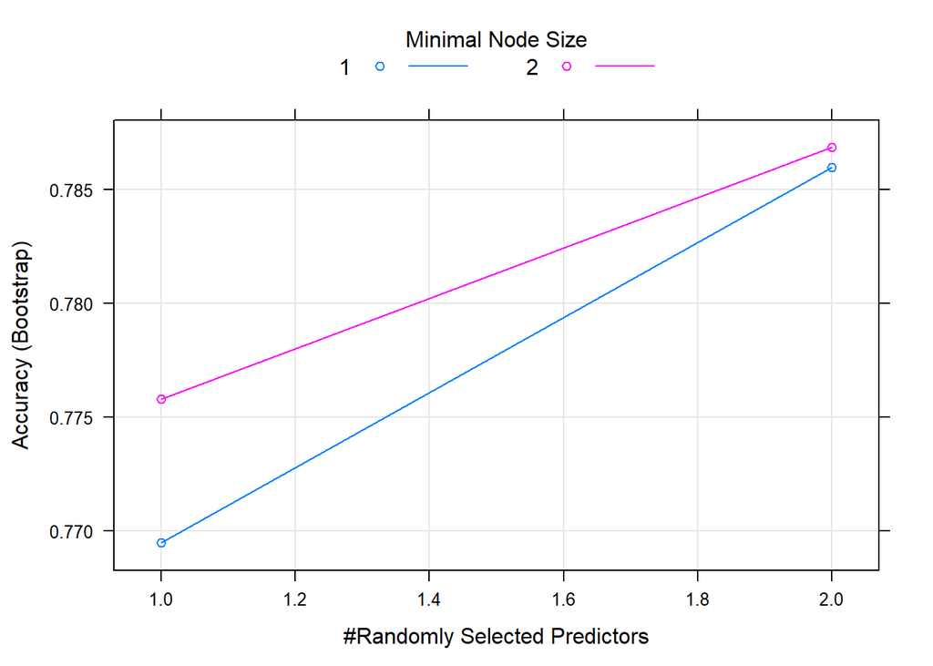

```r
# Plot the tuning result
plot(model)
```

```r
# Used the tuned model for prediction
pred  = predict(model, test)
cm=confusionMatrix(pred, test$target, positive="1")
cm
```

```
## Confusion Matrix and Statistics
##
##           Reference
## Prediction   0   1
##          0 111  25
##          1  16  61
##
##                Accuracy : 0.8075
##                  95% CI : (0.7481, 0.8582)
##     No Information Rate : 0.5962
##     P-Value [Acc > NIR] : 3.607e-11
##
##                   Kappa : 0.5933
##
##  Mcnemar's Test P-Value : 0.2115
##
##             Sensitivity : 0.7093
##             Specificity : 0.8740
##          Pos Pred Value : 0.7922
##          Neg Pred Value : 0.8162
##              Prevalence : 0.4038
##          Detection Rate : 0.2864
##    Detection Prevalence : 0.3615
##       Balanced Accuracy : 0.7917
##
##        'Positive' Class : 1
##
```

Not all parameters of ranger can be tuned with caret. Caret only support to tune three parameters: mtry, splitrule and min.node.size. To see the supported tuning parameters of ranger in caret, one can use this link or use getModelInfo(‘ranger’)$ranger$parameters.

```r
getModelInfo('ranger')$ranger$parameters
```

```
##       parameter     class                         label
## 1          mtry   numeric #Randomly Selected Predictors
## 2     splitrule character                Splitting Rule
## 3 min.node.size   numeric             Minimal Node Size
```

What is the tuning parameter of decision tree rpart2 in caret? Tune this parameter and plot the result. Report the accuracy.

```r
getModelInfo('rpart2')$rpart2$parameters
```

```
##   parameter   class          label
## 1  maxdepth numeric Max Tree Depth
```

```r
# Set the searching range
myGrid = expand.grid(maxdepth = c(1:10))

model <- train(target~.,data = train, method = "rpart2", tuneGrid = myGrid)
print(model)
```

```
## CART
##
## 499 samples
##   8 predictor
##   2 classes: '0', '1'
##
## No pre-processing
## Resampling: Bootstrapped (25 reps)
## Summary of sample sizes: 499, 499, 499, 499, 499, 499, ...
## Resampling results across tuning parameters:
##
##   maxdepth  Accuracy   Kappa
##    1        0.7879509  0.5494751
##    2        0.7861003  0.5358674
##    3        0.7895915  0.5432866
##    4        0.7848728  0.5372300
##    5        0.7840092  0.5390275
##    6        0.7840823  0.5424524
##    7        0.7832128  0.5411943
##    8        0.7825875  0.5405917
##    9        0.7824891  0.5408958
##   10        0.7829395  0.5411166
##
## Accuracy was used to select the optimal model using the largest value.
## The final value used for the model was maxdepth = 3.
```

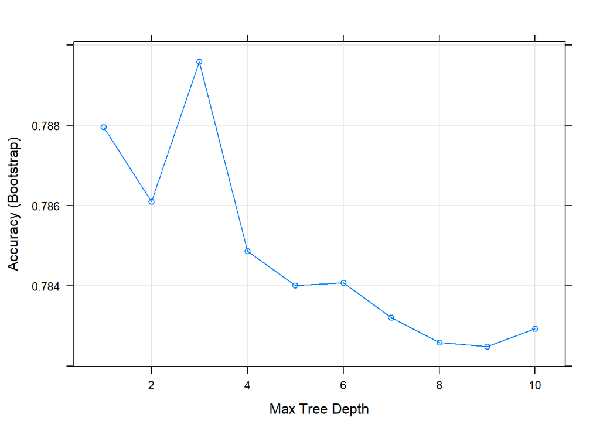

```r
# Plot the tuning result
plot(model)
```